# Ford GoBike Bike sharing data analysis presentation

## by Ephraim Mwai

## Investigation Overview

The data presentation is aimed to answer the following questions;

- Which are the peak hours?
- How does age groups compare in number of bike rides over time?
- What time of the week do we have the highest number of rides for customers and subscribers? Is there a difference between customers and subscribers?

## Dataset Overview

The dataset was gathered from the data source [Ford GoBike](https://s3.amazonaws.com/fordgobike-data/index.html) and merge to a single master data file. The file represents bike rides between stations data from 2017 to 2019(April) for different users across San Francisco, the East Bay and San Jose.

## Which are the peak hours?

> Most frequent trip hours are at 0800hrs and 1700hrs, the time most bike users are commuting to work and back home repectively.

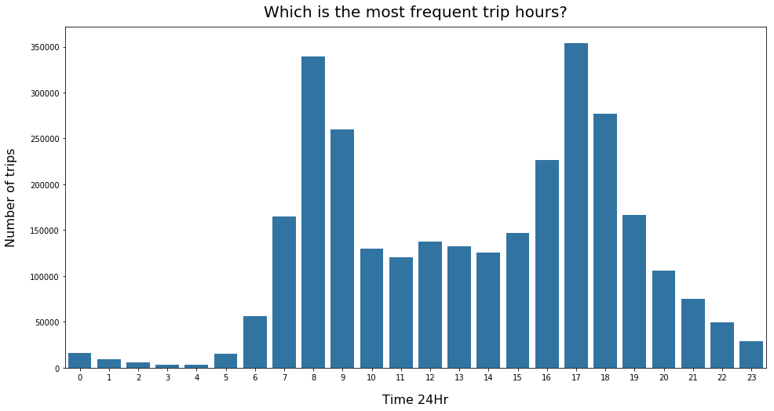

```python
#define a plot color
base_color = sb.color_palette()[0]

plt.figure(figsize=(16,8))
sb.countplot(data = df, x = 'time_hour',color = base_color);
plt.title('Which is the most frequent trip hours?', fontsize= 20, y=1.015);
plt.xlabel('Time 24Hr', labelpad=16, fontsize=16);
plt.ylabel('Number of trips',labelpad=16, fontsize=16);
```

## How does age groups compare in number of bike rides over time?

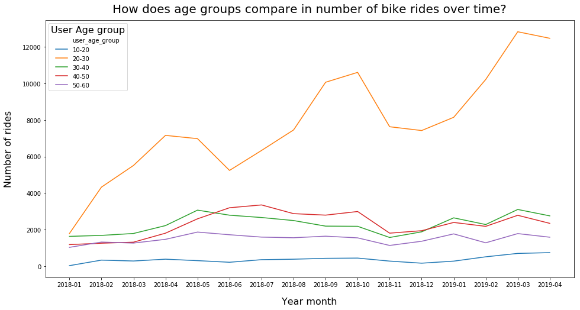

```python
bike_share = df[df['bike_share_for_all_trip']=='Yes'].groupby(['year_month', 'user_age_group']).agg({'bike_id':'count'}).reset_index()

plt.figure(figsize=(16,8))
ax = sb.lineplot(data = bike_share, x='year_month', y='bike_id', hue='user_age_group')
plt.title("How does age groups compare in number of bike rides over time?", fontsize=20, y=1.015)
plt.xlabel('Year month', labelpad=16, fontsize=16);
plt.ylabel('Number of rides', labelpad=16, fontsize=16);
leg = ax.legend()
leg.set_title('User Age group',prop={'size':16});
```

## What time of the week do we have the highest number of rides for customers and subscribers? Is there a difference between customers and subscribers?

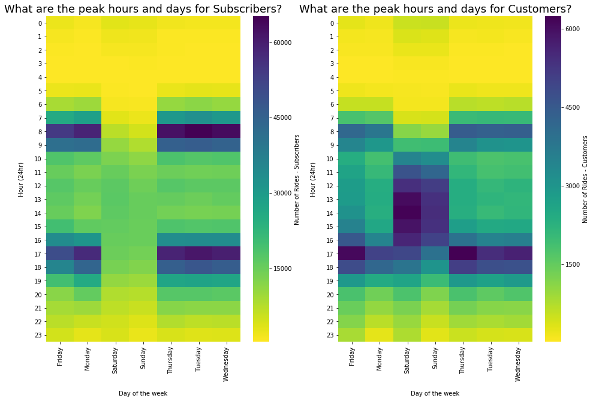

```python
df_subscribers = df[df['user_type'] == 'Subscriber']
df_customers = df[df['user_type'] == 'Customer']

subscribers_day_time_df = df_subscribers.groupby(['user_type','day', 'time_hour']).agg({'bike_id' : 'count'}).rename(columns={'bike_id':'no_of_rides'}).reset_index()
subscribers_day_time_df = subscribers_day_time_df.pivot_table(index='time_hour', columns='day', values='no_of_rides').astype(int)
customers_day_time_df = df_customers.groupby(['user_type','day', 'time_hour']).agg({'bike_id' : 'count'}).rename(columns={'bike_id':'no_of_rides'}).reset_index()
customers_day_time_df = customers_day_time_df.pivot_table(index='time_hour', columns='day', values='no_of_rides').astype(int)

plt.figure(figsize=(16,10))
plt.subplot(121)
sb.heatmap(subscribers_day_time_df, fmt='d',  cmap='viridis_r', annot_kws={"size": 12},  cbar_kws={'label': 'Number of Rides - Subscribers'})
plt.title("What are the peak hours and days for Subscribers?", y=1.2, fontsize=18)
plt.xlabel('Day of the week', labelpad=16)
plt.ylabel('Hour (24hr)', labelpad=16)
plt.yticks(rotation=360);

plt.subplot(122)
sb.heatmap(customers_day_time_df, fmt='d',  cmap='viridis_r', annot_kws={"size": 12},  cbar_kws={'label': 'Number of Rides - Customers'})
plt.title("What are the peak hours and days for Customers?", y=1.015, fontsize=18)
plt.xlabel('Day of the week', labelpad=16)
plt.ylabel('Hour (24hr)', labelpad=16)
plt.yticks(rotation=360);
```